# Tarea 5

Agustín Goycolea - Flavio Navarrete - Catalina Vergara

16 de noviembre de 2018

**PREGUNTA 2**

Se utilizaron las siguientes librerías:

library(pdfetch)

library(tidyverse)

**Parte 1 y 2.a**

1. Descargue el precio de las acciones de Microsoft (“MSFT”) y Apple (“AAPL”) desde Enero del 2000 hasta Agosto del 2018 con periodicidad mensual.
2. Utilizando los datos de 2.1, construya una función que permita:
1. Calcular los retornos

```r
aapl=pdfetch_YAHOO("AAPL",fields="adjclose",from="2000-01-01",interval = "1mo")
msft=pdfetch_YAHOO("MSFT",fields="adjclose",from="2000-01-01",interval = "1mo")

funcion_finanzas<-function(df,retornos=c("yes","no")){
if (retornos=="yes") {
  ret1=log(df/(df-1))
  print(ret1)
}else  if(retornos== "no"){
    ret2 = log((df-(df-1))/(df-1))
    print(ret2)

}
  }

funcion_finanzas(aapl,"no")
```

[output not shown]

**PREGUNTA 3**

**Parte a caso 1**

Calcule E(b<sub>0</sub>),E(b<sub>1</sub>), var(b<sub>0</sub>) y var(b<sub>1</sub>) para muestras de tamaños 50, 100, 500, 1000. ¿Existe sesgo?, ¿Desaparece el sesgo a medida que el tama?o de la muestra aumenta?

| Tamano_muestral | E_b0 | E_b1 | V_b0 | V_b1 | Sesgo_b0 | Sesgo_b1 |
| --- | --- | --- | --- | --- | --- | --- |
| 50 | 1.966561 | 3.301664 | 16.5321815 | 0.0412414 | -0.0334388 | 0.8016640 |
| 100 | 1.989522 | 3.300577 | 8.1138592 | 0.0202360 | -0.0104777 | 0.8005768 |
| 500 | 1.990924 | 3.300468 | 1.6007458 | 0.0039923 | -0.0090763 | 0.8004682 |
| 1000 | 1.988673 | 3.300563 | 0.8030073 | 0.0020006 | -0.0113266 | 0.8005631 |

**Parte b caso 1**

Grafique la distribución de B<sub>1</sub> para tamaños de muestra n = 50, 100, 500, 1000

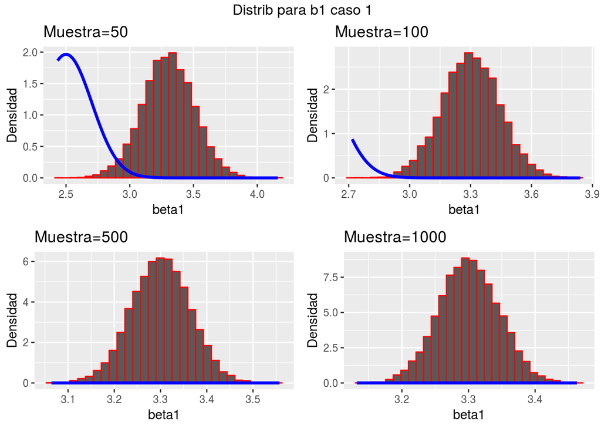

Se observa que al aumentar el tamaño muestral, el intervalo en el que se encuentra la distribución de b1, va disminuyendo y concentrandose en mayor medida en torno a la media.

**Parte a caso 2**

| Tamano_muestral | E_b0 | E_b1 | V_b0 | V_b1 | Sesgo_b0 | Sesgo_b1 |
| --- | --- | --- | --- | --- | --- | --- |
| 50 | 2.495506 | 2.500266 | 9.4635674 | 0.0236196 | 0.4955059 | 0.0002663 |
| 100 | 2.498599 | 2.500041 | 4.4022467 | 0.0109705 | 0.4985987 | 0.0000413 |
| 500 | 2.491758 | 2.500402 | 0.8775837 | 0.0021897 | 0.4917580 | 0.0004017 |
| 1000 | 2.491570 | 2.500427 | 0.4370810 | 0.0010879 | 0.4915697 | 0.0004268 |

**Parte b caso 2**

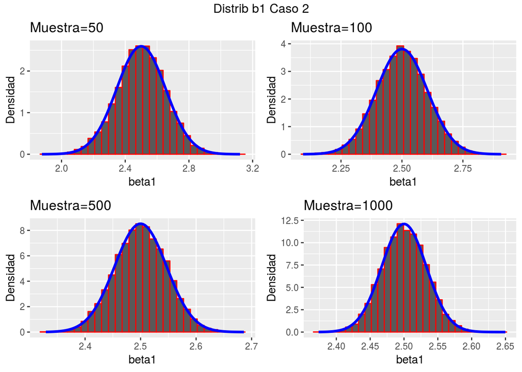

Es posible observar que la media varía con la distribución uniforme de x<sub>2</sub>, por que logra capturar el efecto que no se incluía en el caso 1.